# 21.13. Контурные сферы Тихомирова и годографы исторической 4D-КТ

**Вычислительный эксперимент; разработка методики.** Проверено, как математические способы подгонки двумерной окружности, сохранённые в коде Тихомирова, ведут себя на пофазных контурах крови сердца из архивной 4D-КТ. Расчёт позволяет сопоставить *геометрические* траектории центров разных определений на одних и тех же изображениях. Он не восстанавливает центр из электроимпедансных сигналов и не устанавливает совпадение с опубликованными годографами РФФИ.

**Главное наблюдение.** Центр окружности по контуру и объёмный центр маски дают различающиеся траектории, особенно во фронтальной проекции. Следовательно, выбор геометрического определения центра сам по себе влияет на годограф; совпадение или расхождение с электрическим годографом нельзя приписывать только качеству обратной задачи.

## Историческая методика и граница её восстановления

В диссертации Тихомирова единая сфера представляла кровь желудочков вместе с кровью предсердий. Предсистолический контур строили по сагиттальному МРТ-изображению и проектировали относительно электродов. Из десяти характерных точек семь описывали желудочки: две точки клапанного кольца и пять пересечений контура с осями электродных систем; ещё три относились к предсердиям. Сравнивали (1) совместную подгонку центра и радиуса методом наименьших квадратов радиальных отклонений и (2) центр площади контура с радиусом окружности равной площади. В исходном эксперименте автор предпочёл аппроксимацию общей крови желудочков и предсердий методом наименьших квадратов по критерию перемещения границы; этот вывод относится к тем МРТ и электродным осям. Для проверки движения использовали пять импедансных каналов, параметры мягких тканей и минимум суммы квадратов разности модельных и измеренных изменений импеданса. Весь кардиоцикл делили на 25 интервалов. Диссертация, § 4.2–4.5; отчёт РФФИ, § 5.2–5.3.

**Прямая и обратная задачи не тождественны геометрической подгонке контура.** Основная аналитическая электрическая модель использовала однородное полупространство с эффективным сопротивлением $\rho_1$ и сферу крови с сопротивлением $\rho_2$. Для каждой фазы электрическая обратная задача подбирала изменения радиуса и трёх координат центра по пяти измеренным изменениям импеданса; по 25 оценкам центра строился годограф. Отдельный канал кровенаполнения мягких тканей использовался для поправки на изменение внешней среды. В модели отсутствуют отдельные объёмы костей и лёгких, а также раздельные области мышц и миокарда. Это *однослойность геометрии внешней среды*, несмотря на наличие двух электрических материалов — среды и сферы. Диссертация, § 2.1 и 4.4–4.5; код прямых моделей.

**Обоснование и граница допущения.** Автор сообщает об измерениях *на выдохе* и мотивирует объединение окружающих тканей тем, что сопротивление лёгких на выдохе приближается к сопротивлениям миокарда и мышц. В его таблице для 100 кГц приведены 3,68 Ом·м для лёгких на выдохе, 4,6 Ом·м для миокарда и среднее 2,7 Ом·м для мышц; для последующих расчётов мягких тканей принято эффективное значение 4,2 Ом·м. **Равенство проводимостей не утверждалось.** Автор настоящего проекта уточнил, что измерения проводились *на глубоком выдохе*; в проверенном фрагменте диссертации глубина выдоха не указана, поэтому это уточнение требует проверки по протоколу. Отдельно исследована двуслойная постановка с жиром и сферой в ANSYS, но сохранённые аналитические функции `TwoLayerModel` и `SphereModel` не составляют единого решателя полной двуслойной обратной задачи со сферой. Следовательно, опубликованный годограф нельзя считать прямой траекторией анатомического центра или доказательством пренебрежимо малого влияния неоднородных тканей. Диссертация, § 2.1 и 2.3; правила сопоставления.

Исходный Wolfram-код `SphereMovingFunction.m` действительно содержит критерий

$$E(\mathbf c,r)=\sum_{i=1}^{n}(\|\mathbf p_i-\mathbf c\|-r)^2,$$

а также варианты с фиксированным центром и радиусом по площади. В Python-переносе `cardio-model-py` сохранены эти операции. На текущем окружении его проверка дала **235 пройденных тестов**; это проверка переноса вычислительного ядра и исторических численных примеров, а не проверка его работы на наших КТ или электродных сборках. Просмотренный код не содержит завершённого совместного пофазного восстановления $(\Delta r,\Delta x,\Delta y,\Delta z)$ из пяти каналов по критерию диссертации. В `IMPdata.m` имеются 25 значений пятиканального сигнала и таблично сохранённая последовательность параметров для одного исторического примера, но отсутствует подтверждённая связь этих чисел с тремя сериями КТ, исследуемыми ниже.

## Что именно перенесено на 4D-КТ

**Измеренные данные:** исходные пофазные КТ трёх архивных серий, по 20 реконструкций цикла. **Автоматически рассчитанные данные:** маски крови четырёх камер TotalSegmentator v2, их объединение и отдельно объединение желудочков. Перегородки специальной морфологической процедурой не заполнялись. Перед использованием каждой фазы проверены хэши КТ и всех четырёх камерных масок, совпадение аффинного преобразования и полнота фаз. Это контроль файлов и координат, а не независимая валидация точности каждой границы.

Для каждой фазы маску проектировали на сагиттальную плоскость $(S,A)$ или фронтальную $(R,S)$ в системе NIfTI RAS+. Чтобы получить единую внешнюю огибающую отделённых камер, брали выпуклую оболочку проекции. Её границу равномерно пересэмплировали по длине дуги на 128 точек; дополнительный вариант использует 7 равномерных точек. Затем вызывали функции существующего Python-переноса `EqualSphere`: совместная МНК-подгонка, центр и радиус по площади, а также подгонка радиуса при фиксированном центре площади. Начало локальных координат было одним и тем же для всех фаз серии — объёмный центр маски первой фазы. Параметрические границы исторического переносного кода сохранены.

**Ключевое допущение:** такая внешняя оболочка и равномерные точки заменяют ручные МРТ-ориентиры лишь для проверки математического критерия. Они не воспроизводят исходный выбор пяти электродных осей, конкретный срез и исходную процедуру получения десяти точек. Выпуклая оболочка может добавлять площадь и не является исторической процедурой заполнения перегородок. Радиус окружности по двумерной проекции не обязан сохранять объём трёхмерной крови.

## Рисунок 1. Почему различаются центры

Показана первая фаза первой архивной серии. Тёмная линия — внешняя огибающая проекции четырёх камер; синий пунктир — окружность наименьших квадратов; оранжевый пунктир — окружность равной площади; чёрный ромб — объёмный центр исходной маски. Фиолетовые точки показывают вариант с семью *равномерными*, а не историческими электродными ориентирами. Сагиттальная и фронтальная проекции дают разные двумерные объекты, поэтому центры и радиусы нельзя переносить между ними.

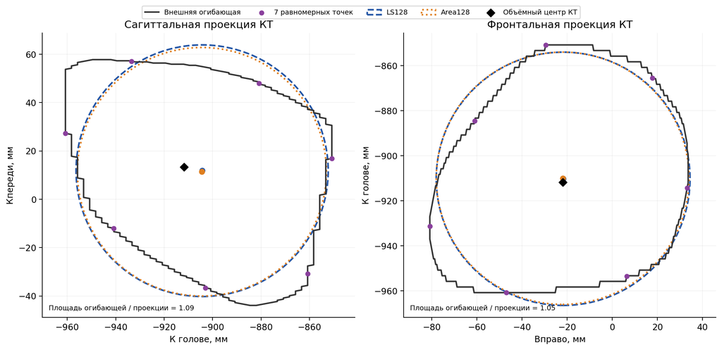

## Показатель сопоставления траекторий

Для каждого способа центр проекции $\mathbf c_k(t)$ сравнивался с проекцией объёмного центра маски $\mathbf m(t)$ после вычитания собственного начального положения. Показана среднеквадратичная **разница смещений**:

$$D=\sqrt{\frac{1}{N}\sum_t\left\|[\mathbf c_k(t)-\mathbf c_k(0)]-[\mathbf m(t)-\mathbf m(0)]\right\|^2}.$$

Отдельно рассчитано смещение между абсолютными центрами. Эти числа характеризуют **различие двух определений центра на одной автоматической маске**, а не ошибку относительно независимого истинного положения сердца. Нулевая разница не доказывала бы электрической эквивалентности сферической формы.

## Рисунок 2. Полученные по КТ годографы

Линии показывают смещение относительно первой фазы каждой серии. Квадраты отмечают начало реконструированного цикла; последующие точки идут через 5% диапазона фаз. Чёрный годограф относится к объёмному центру крови, синий — к окружности наименьших квадратов, оранжевый — к окружности равной площади. Все кривые в каждой панели получены **из одной и той же маски**; различие обусловлено определением центра и проекцией. Связывать их физиологические отметки с R-зубцом отчёта РФФИ без фазовой регистрации нельзя.

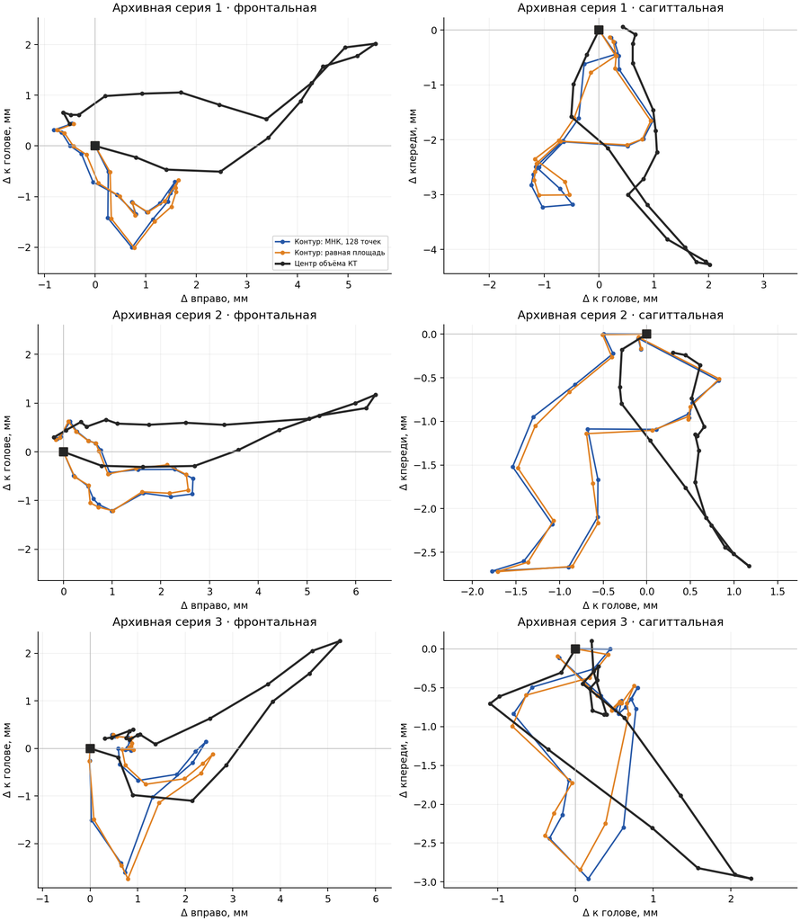

## Численный результат

| Серия | КТ, макс. смещение во фронтальной плоскости, мм | МНК-128, макс. смещение, мм | Различие траекторий во фронтальной плоскости, мм | Различие траекторий в сагиттальной плоскости, мм |
| --- | --- | --- | --- | --- |
| Архивная серия 1 | 5.89 | 2.13 | 2.78 | 1.65 |
| Архивная серия 2 | 6.51 | 2.78 | 2.40 | 1.28 |
| Архивная серия 3 | 5.72 | 2.71 | 1.88 | 1.03 |

Для совместной МНК-подгонки на 128 точках различие смещений во фронтальной плоскости составило **1.88–2.78 мм**; в сагиттальной — **1.03–1.65 мм**. Во всех трёх сериях максимальный размах фронтального смещения центра МНК-окружности меньше размаха объёмного центра маски. Это не доказательство занижения электрически восстановленного движения: сравниваются разные геометрические определения. Замена 128 точек семью равномерными меняла показатель $D$ не более чем на 0.48 мм в изученных сериях; исходные семь точек Тихомирова были привязаны к электродным осям, поэтому этот тест не оценивает именно их влияние. Все 960 пофазных вариантов вычислены; в совместной МНК-подгонке верхняя граница радиуса исторического кода не достигалась.

## Рисунок 3. Различие смещений для всех контурных вариантов

Цвет и подписанное значение показывают $D$ в миллиметрах; шкала общая для двух панелей. «Площадь-128» и «Центр-128» имеют одинаковую траекторию центра **по определению**: оба фиксируют центр площади контура, но дают различный радиус. Поэтому одна только матрица годографов не может выбрать между этими вариантами. Для такого выбора необходим анализ изменения радиуса, формы и затем электрического отклика.

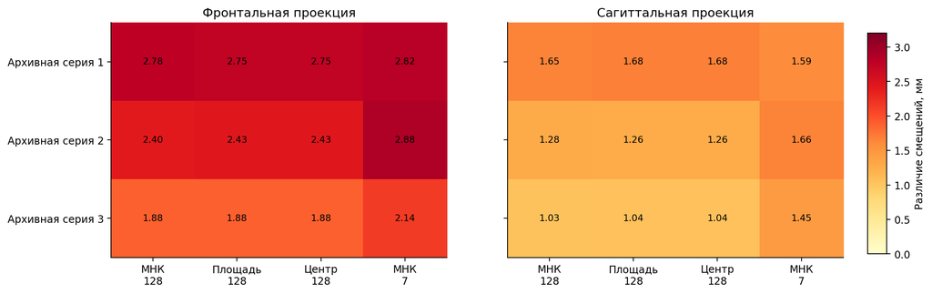

## Рисунок 4. Что меняется при исключении предсердий

Для каждой серии показан максимальный размах от первой фазы отдельно для объёмного центра КТ и центра окружности МНК-128. Чёрные и синие столбцы относятся к объединённой крови четырёх камер, серые и оранжевые — только к крови желудочков. В четырёхкамерной области окружность во всех трёх сериях имеет меньший фронтальный размах, чем объёмный центр; в желудочковой области — больший. Это демонстрирует сильную зависимость закона движения от **определения замещаемой области**. Указанные размахи принадлежат разным объектам; меньшая разница между столбцами сама по себе не доказывает физиологического или электрического преимущества метода.

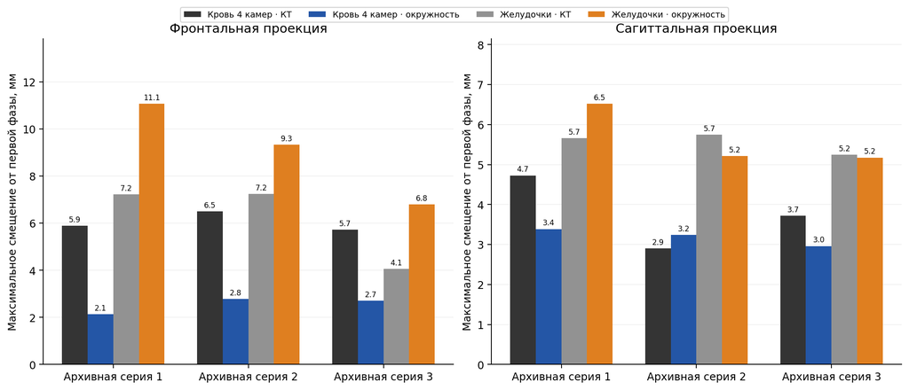

## Рисунок 5. Изменение радиуса окружности

На графиках отложен радиус МНК-окружности относительно первой фазы. Различие между фронтальной и сагиттальной кривой одного человека ожидаемо: это радиусы **окружностей двумерных проекций**, а не оценки одного и того же трёхмерного радиуса сферы. Даже если две кривые центров совпадают, разные законы изменения радиуса могут дать разные электрические сигналы. Применять формулу объёма шара к этим радиусам без отдельного правила перехода от 2D к 3D неправомерно.

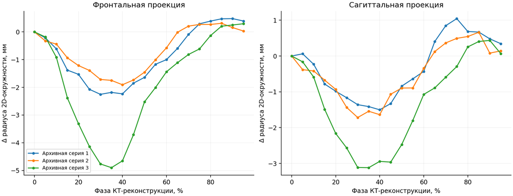

## Сопоставление с РФФИ и ограничения вывода

В РФФИ опубликованы годографы, восстановленные **из пяти электрических каналов**, а здесь — центры, рассчитанные **из КТ-геометрии**. Это разные определяемые объекты. На рисунке 25 отчёта ось $x$ показана горизонтально, $y$ — вертикально; в тексте диссертации (§ 4.4) $x$ названа вертикальной осью тела, $y$ — фронтальной, $z$ — сагиттальной. Согласованное преобразование между этими историческими координатными записями и RAS+ пока не документировано. Пары «доброволец РФФИ — архивная серия 4D-КТ», независимой синхронизации 25 электрических интервалов с 20 КТ-фазами и одинакового определения исходной области также нет. Поэтому **числовую ошибку относительно опубликованных годографов вычислять нельзя**; их рисунки остаются гипотезой о масштабе и характере движения. Рис. 27, 29, 31 РФФИ; свод правил сопоставления осей.

В этом опыте нет независимой ручной проверки каждого пофазного контура и его центра, нет количественной модели погрешности сегментации, измеренного шума каналов и проверки электрического поля. Выпуклая оболочка добавляла к площади проекции около нескольких процентов, заполняя вогнутости. Изменение плоскости и правила точек может изменить вывод; выбор «лучшего» метода по одной матрице $D$ был бы необоснованным.

**Следующая доступная проверка:** на одной и той же КТ, материальной карте и выбранных сборках вычислить в EIDORS синтетический отклик анатомической области и каждой сферы. Далее решать обратную задачу на этих синтетических сигналах, оценивать погрешности восстановления смещения центра и изменения объёма, а также их взаимную неидентифицируемость. Координаты и сигналы исторического пятиканального опыта у нас отсутствуют; получение их от автора не предполагается. Жёстко сохранённые в историческом коде числа могут служить только внутренним примером проверки формул с установленным происхождением, но не референсом для архивных КТ. Прямое численное расхождение с РФФИ до документального сопоставления людей, координат и фаз останется неопределённым. Проверка на синтетическом EIDORS устанавливает свойства модели в заданной постановке, а не экспериментальную точность реального прибора.

## Воспроизведение и происхождение

Расчётное ядро: `run_tikhomirov_ct_contours.py`, построение рисунков и отчёта: `build_tikhomirov_ct_report.py`. Исходный порт: `sphere_fit.py`; первичный Wolfram-файл: `SphereMovingFunction.m`. Идентичность первоисточников зафиксирована в реестре диссертации и отчётов. Локальный протокол с хэшами кода и конфигурации — `results/tikhomirov_audit_20260928/fit_v2/protocol.json`; пофазные параметры — `phase_fits.csv`, сводка — `summary.csv`. Конфигурация указывает на внешние локальные маски и не публикуется. Пересчёт: `python run_tikhomirov_ct_contours.py --config <локальная конфигурация> --output <пустая папка>`, затем `python build_tikhomirov_ct_report.py`. Опубликованные значения в этом ноутбуке — сохранённый результат указанного прогона; повторное открытие HTML его не пересчитывает.